# Bank Modelling_Decodr_15-Jun-2020-Final_Submission_Debasish_Goswami

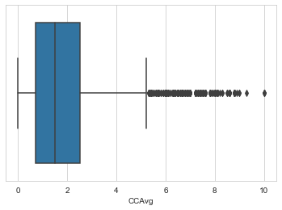

```python
sns.set_style('whitegrid')
sns.boxplot(df['CCAvg'])
```

```python
df['CCAvg'].describe()
```

```
count    5000.000000
mean        1.937938
std         1.747659
min         0.000000
25%         0.700000
50%         1.500000
75%         2.500000
max        10.000000
Name: CCAvg, dtype: float64
```

```python
df['CCAvg'].skew()
```

```
1.5984433366678663
```

- CCAvg feature is rightly skewed Not following Normal distribution.
- Most of the target customers are having monthly spending average in between 0 to 5 and
- outlier May present above 5.
- We can take log transfor of this feature later.

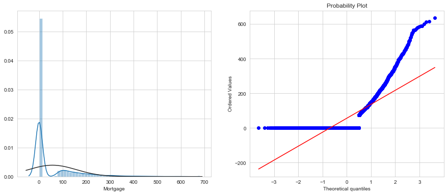

```python
plt.figure(figsize=(15,6))
plt.subplot(1,2,1)
sns.distplot(df['Mortgage'],fit=norm)
plt.subplot(1,2,2)
stats.probplot(df['Mortgage'],dist='norm',plot=plt)
plt.show()
```

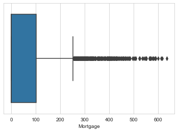

```python
sns.boxplot(df['Mortgage'])
```

```python
df['Mortgage'].describe(percentiles=[0.25,0.5,0.75,0.95])
```

```
count    5000.000000
mean       56.498800
std       101.713802
min         0.000000
25%         0.000000
50%         0.000000
75%       101.000000
95%       272.000000
max       635.000000
Name: Mortgage, dtype: float64
```

```python
df['Mortgage'].skew()
```

```
2.1040023191079444
```

- Mortgage is Not following the diagonal line
- Variable is showing Peakedness, right skewness.
- 50% of the target customer don't have any mortage.
- Mortgage is having heavy outliers presence above 300 and We may take log transform of this variable later.

```python
df['Securities Account'].value_counts (normalize=True)
```

```
0    0.8956
1    0.1044
Name: Securities Account, dtype: float64
```

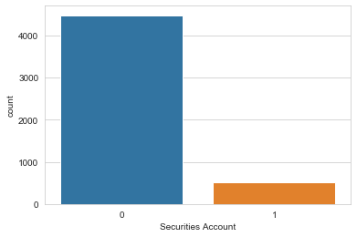

```python
sns.countplot(df['Securities Account'])
```

89% of the Targeted customers don't have Securities Account.

```python
df['CD Account'].value_counts (normalize=True)
```

```
0    0.9396
1    0.0604
Name: CD Account, dtype: float64
```

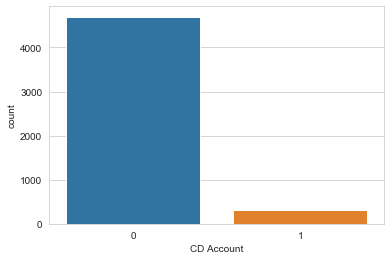

```python
sns.countplot(df['CD Account'])
```

```python
df['Online'].value_counts (normalize=True)
```

```
1    0.5968
0    0.4032
Name: Online, dtype: float64
```

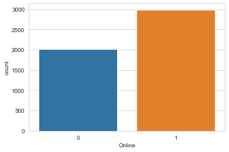

```python
sns.countplot(df['Online'])
```

59% of the Customers have Internet banking facilities.

```python
df['CreditCard'].value_counts (normalize=True)
```

```
0    0.706
1    0.294
Name: CreditCard, dtype: float64
```

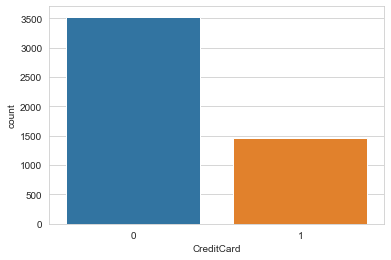

```python
sns.countplot(df['CreditCard'])
```

70% of the customers don't have credit card.

```python
df['Education'].value_counts (normalize=True)
```

```
1    0.4192
3    0.3002
2    0.2806
Name: Education, dtype: float64
```

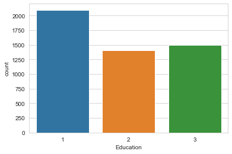

```python
sns.countplot(df['Education'])
```

### Distribution Of Output Variable:

```python
df['Personal Loan'].value_counts()
```

```
0    4520
1     480
Name: Personal Loan, dtype: int64
```

```python
df['Personal Loan'].value_counts (normalize=True)
```

```
0    0.904
1    0.096
Name: Personal Loan, dtype: float64
```

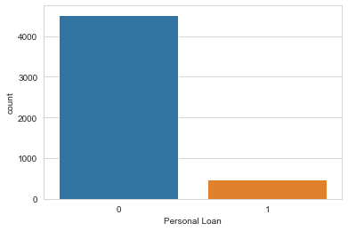

```python
sns.countplot(df['Personal Loan'])
```

- In Our given data Majority of the customers 90% don't have personal loan, and only 10% is choosen personal loan.
- The Data is un-balanced.

## Bi-Variate Analysis:

```python
df.columns
```

```
Index(['ID', 'Age', 'Experience', 'Income', 'ZIP Code', 'Family', 'CCAvg',
       'Education', 'Mortgage', 'Personal Loan', 'Securities Account',
       'CD Account', 'Online', 'CreditCard'],
      dtype='object')
```

```python
df.info()
```

```
<class 'pandas.core.frame.DataFrame'>
RangeIndex: 5000 entries, 0 to 4999
Data columns (total 14 columns):
ID                    5000 non-null int64
Age                   5000 non-null int64
Experience            5000 non-null int64
Income                5000 non-null int64
ZIP Code              5000 non-null int64
Family                5000 non-null int64
CCAvg                 5000 non-null float64
Education             5000 non-null int64
Mortgage              5000 non-null int64
Personal Loan         5000 non-null int64
Securities Account    5000 non-null int64
CD Account            5000 non-null int64
Online                5000 non-null int64
CreditCard            5000 non-null int64
dtypes: float64(1), int64(13)
memory usage: 547.0 KB
```

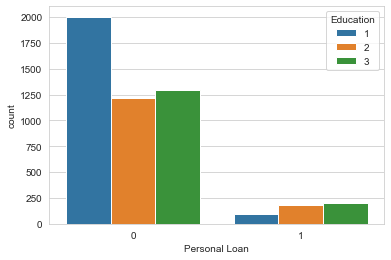

```python
sns.countplot(x='Personal Loan',hue='Education',data=df)
```

```python
x=pd.crosstab(df['Personal Loan'],df['Education'],normalize='columns')
print(x)
print('*'*50)
print(stats.chi2_contingency(x))
```

```
Education            1         2         3
Personal Loan
0              0.95563  0.870278  0.863424
1              0.04437  0.129722  0.136576
(0.05685436623287337, 0.9719730676190449, 2, array([[0.89644404, 0.89644404, 0.89644404],
       [0.10355596, 0.10355596, 0.10355596]]))
```

Customers with higher education level have opted more for Personal loan and Education has no association with Personal Loan.

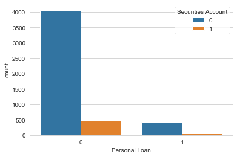

```python
sns.countplot(x='Personal Loan',hue='Securities Account',data=df)
```

```python
x=pd.crosstab(df['Personal Loan'],df['Securities Account'],normalize='columns')
print(x)
print('*'*50)
print(stats.chi2_contingency(x))
```

```
Securities Account         0         1
Personal Loan
0                   0.906208  0.885057
1                   0.093792  0.114943
(5.125163079509029, 0.023581354709620635, 1, array([[0.8956328, 0.8956328],
       [0.1043672, 0.1043672]]))
```

```python
df.columns
```

```
Index(['ID', 'Age', 'Experience', 'Income', 'ZIP Code', 'Family', 'CCAvg',
       'Education', 'Mortgage', 'Personal Loan', 'Securities Account',
       'CD Account', 'Online', 'CreditCard'],
      dtype='object')
```

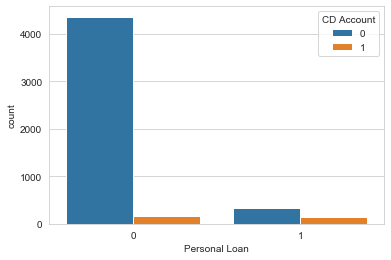

```python
sns.countplot(x='Personal Loan',hue='CD Account',data=df)
```

```python
x=pd.crosstab(df['Personal Loan'],df['CD Account'],normalize='columns')
print(x)
print('*'*50)
print(stats.chi2_contingency(x))
```

```
CD Account            0         1
Personal Loan
0              0.927629  0.536424
1              0.072371  0.463576
(0.9446988801085484, 0.33107233250981855, 1, array([[0.73202631, 0.73202631],
       [0.26797369, 0.26797369]]))
```

- 46% of the Customers who have CD account have opted for personal Loan.
- P value is greater than 0.05, So null hypothesis is not rejected here, But we'll take it forward.

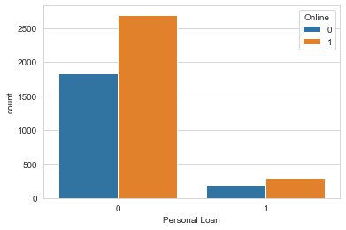

```python
sns.countplot(x='Personal Loan',hue='Online',data=df)
```

```python
x=pd.crosstab(df['Personal Loan'],df['Online'],normalize='columns')
print(x)
print('*'*50)
print(stats.chi2_contingency(x))
```

```
Online               0        1
Personal Loan
0              0.90625  0.90248
1              0.09375  0.09752
(5.737574214022258, 0.016605711264257517, 1, array([[0.90436495, 0.90436495],
       [0.09563505, 0.09563505]]))
```

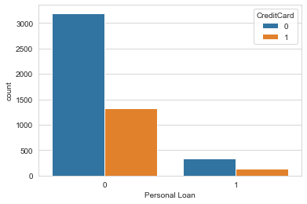

```python
sns.countplot(x='Personal Loan',hue='CreditCard',data=df)
```

```python
x=pd.crosstab(df['Personal Loan'],df['CreditCard'],normalize='columns')
print(x)
print('*'*50)
print(stats.chi2_contingency(x))
```

```
CreditCard            0         1
Personal Loan
0              0.904533  0.902721
1              0.095467  0.097279
(5.720709421932652, 0.01676595489837495, 1, array([[0.90362683, 0.90362683],
       [0.09637317, 0.09637317]]))
```

#### Bi-Variate with Continuous Variables:

*Age:*

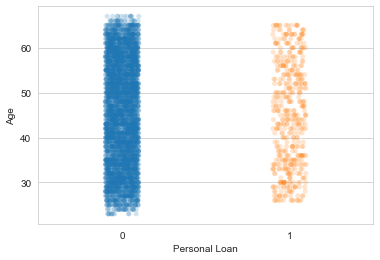

```python
sns.stripplot(x='Personal Loan',y='Age',data=df,alpha=0.2,jitter=True)
plt.show()
```

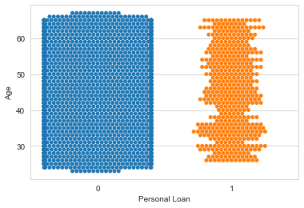

```python
sns.swarmplot(x='Personal Loan',y='Age',data=df)
```

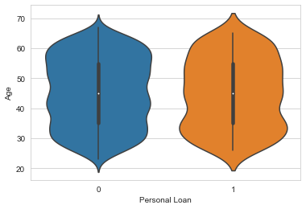

```python
sns.violinplot(x='Personal Loan',y='Age',data=df,size=8)
plt.show()
```

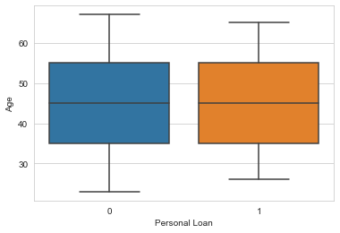

```python
sns.boxplot(x = 'Personal Loan', y = 'Age', data = df)
```

```python
df[df['Age']<26]['Personal Loan'].value_counts()
```

```
0    93
Name: Personal Loan, dtype: int64
```

```python
df[df['Age']>65]['Personal Loan'].value_counts()
```

```
0    36
Name: Personal Loan, dtype: int64
```

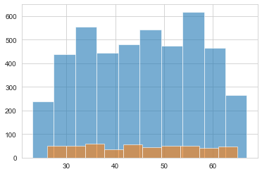

```python
df.groupby('Personal Loan')['Age'].hist(alpha=0.6)
plt.show()
```

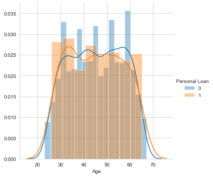

```python
sns.FacetGrid(df,hue='Personal Loan',height=5).map(sns.distplot,'Age').add_legend()
```

```python
cat1=df[df['Personal Loan']==0]
cat2=df[df['Personal Loan']==1]

ttest_ind(cat1['Age'],cat2['Age'])
```

```
Ttest_indResult(statistic=0.5461906615539323, pvalue=0.584959263705325)
```

- At the age of below 26 and at the age greater than 65 peoples are not taking personal loan and that is quite obvious.

```python
df.columns
```

```
Index(['ID', 'Age', 'Experience', 'Income', 'ZIP Code', 'Family', 'CCAvg',
       'Education', 'Mortgage', 'Personal Loan', 'Securities Account',
       'CD Account', 'Online', 'CreditCard'],
      dtype='object')
```

*Experience:*

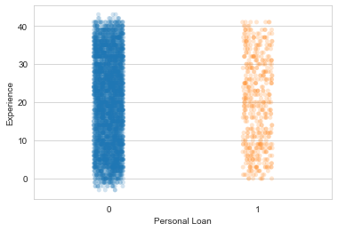

```python
sns.stripplot(x='Personal Loan',y='Experience',data=df,alpha=0.2,jitter=True)
plt.show()
```

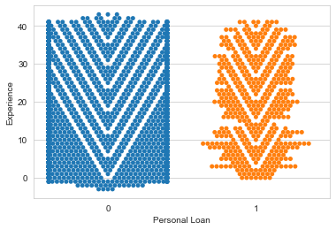

```python
sns.swarmplot(x='Personal Loan',y='Experience',data=df)
```

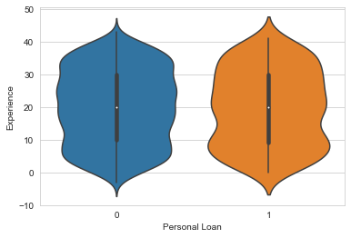

```python
sns.violinplot(x='Personal Loan',y='Experience',data=df,size=8)
plt.show()
```